# R&D-Networks

## Endogenous Technology Spillovers in R&D Collaboration Networks

`by Hsieh, Konig and Liu (2023, RAND forthcoming)`

**Zhiyuan Chen**

*School of Business*

*Renmin University of China*

## Roadmap

- **A Gentle Introduction to Structural Modeling and Estimation**
- **The Paper in a Nutshell**
- **Theory**
- **Estimation**
- **Conclusion**

## A Gentle Introduction to Structural Modeling and Estimation

- **Reduced-form Methods**:
  - Focus on estimating the causal effect of a treatment ($X$) on an outcome ($Y$).
  - Do not explicitly model the underlying mechanisms.
  - e.g., OLS, IV, RDD, matching, etc.
- **Structural Methods**:
  - Focus on estimating the structural parameters of a model that describes the relationship between $X$ and $Y$.
  - Explicitly model the underlying mechanisms
  - Counterfactual analysis for policy evaluation and welfare analysis
  - e.g., demand estimation, dynamic programming, quantitative trade models, etc.

## Connecting Model with Data: A Comparison

| Features | Reduced-form Model | Structural Model |
| --- | --- | --- |
| *Data Generation Process* | $Y_i = f(X_i) + \varepsilon_i$ | $X_i = argmax_{z} \{U(Y_i, z)\}$ |
| *Estimation Purpose* | Causal effect of $X$ on $Y$ | Structural parameters of the model |
| *Estimation Method* | OLS, IV, RDD, Matching | GMM, MLE, MCMC |
| *Advantages* | Easy to implement, interpret, and understand | More flexible, can incorporate more information, can be used for counterfactual analysis |
| *Disadvantages* | mechanisms? mis-specification? General equilibrium effects? | Usually more complicated, requires more assumptions, overfitting problem |

## The Paper by Hsieh, Konig and Liu (2023) in a Nutshell

- **Research Question**: How to account for the co-evolution of R&D networks and firms' R&D expenditures in a model that can be applied to the real-world data?
- **Key Contributions**:
  - Develop a structural model of R&D collaboration networks that incorporates endogenous production, R&D investment and collaboration decisions.
  - A complete equilibrium characterization of the model, consistent with the observed R&D networks
    - *nested* R&D network structures
    - *Pareto* distributed output levels
    - Competitive equilibrium exhibits *under-connected* R&D networks
  - An estimation strategy that is computationally feasible for large-scale networks
  - Counterfactual analysis of R&D subsidy, showing R&D subsidy targeting critical R&D collaborations is **much more effective (5 times larger!)** than a uniform (ignorant of network structure) R&D subsidy policy

## Theory

Without the dynamics, the model is an extended Cournot model with R&D collaboration networks.

- **Firm Profits**: $$\pi_i(\mathbf{y}, G)= \underbrace{\eta_i y_i}_{\text{private cost reductions}}-\frac1{2}y_i^2-\underbrace{\color{blue}\lambda y_i\sum_{j\neq i}y_j}_{\text{\color{blue}product market competition}} +\underbrace{{\color{red}\rho y_i \sum_{j=1}^n a_{ij}y_j}}_{\text{\color{red}spillovers due to cooperation}} -\underbrace{\zeta \sum_{j=1}^n a_{ij}}_{\text{\color{green}R\&D collaborations}}$$
  - R\&D collaboration network $\mathbf{A} = (a_{ij})$ is a binary matrix, where $a_{ij} = 1$ if $i$ collaborates with firm $j$, and $0$ otherwise; $a_{ii}=0$.
  - NO knowledge spillover if NO collaboration ($a_{ij} =0$), $\text{\color{red}inconsistent with the real-world patent citations and tons of empirical evidence on knowledge spillovers}(e.g., Liu and Ma (2021))$

## Theory (cont'd)

> **(Myopic) Best Response Dynamics**: A sequence of R&D efforts $\mathbf{y}_t$ and collaboration network $G_t$ such that in $[t, t+\Delta t]$:
> - **R\&D Choice** (type-I extreme value shocks): $$\Pr(y,\mathbf{y}_{-it}, G_t|\mathbf{y}_{t-1}, G_t) = \chi \frac{e^{\vartheta \pi_i(y, \mathbf{y}_{-it},G_t)}}{\int_{\mathcal{Y}}e^{\vartheta \pi_i(y', \mathbf{y}_{-it},G_t)}dy'}+ o(\Delta t)$$
> - **Collaboration Choice** (type-I extreme value shocks): $$\Pr(\mathbf{y}_t, G_t'|\mathbf{y}_t, G_t) = \xi \frac{e^{\vartheta \Phi(\mathbf{y}_{t},G_t')}}{e^{\vartheta \Phi(\mathbf{y}_{t},G_t}+e^{\mathbf{y}_{t},G_t'})}+ o(\Delta t)$$
- The potential function $\Phi(\mathbf{y}, G)$ aggregates the R&D efforts and collaboration network
- The R&D choice is static, much like choice of intermediate inputs, no dynamic implications for future output levels

## Theory (cont'd)

> **Stationary Distribution**: $(\mathbf{y}_t, G_t)$ is an ergodic Markov Chain with a unique stationary distribution $\mu^{\vartheta}(\mathbf{y}, G)$ given by the *Gibbs measure*:$$ \mu^{\vartheta}(\mathbf{y}, G) = \frac{e^{\vartheta \Phi(\mathbf{y}, G)}}{\sum_{G'\in \mathcal{G}^n \int_{\mathcal{Y}^n}e^{\vartheta \Phi(\mathbf{y}', G')d\mathbf{y}'}}}$$
- Directly computing $\mu^{\vartheta}(\mathbf{y}, G)$ is costly, especially for large networks (the denominator)
- Use the *composite likelihood* method to compute conditional distributions:
  - $\mu^{\vartheta}(\mathbf{y}|G) $ is a joint normal distribution
  - $\mu^{\vartheta}(G|\mathbf{y})$ a product of "independent" pairwise independent linking probabilities $$\Pr(a_{ij}=1|\mathbf{y}) = \frac{e^{\vartheta \Phi(\rho y_i y_j -\zeta)}}{1+e^{\vartheta \Phi(\rho y_i y_j -\zeta)}}$$

## Theory (cont'd)

> **Equilibrium Characterization**: $\vartheta\rightarrow \infty$ (i.e., small noise), $G$ is a nested split graph:$$ a_{ij} = \mathbf{1}_{\{\rho y_i y_j>\zeta\}}$$ $$y_i = \eta_i + \sum_{j\neq i}^n y_{j}(a_{ij}y_j - \lambda)$$
- Echos the **core-periphery** structure of real-world R&D networks
- **Policy Implication**: The equilibrium R&D spending is too low compared to the socially optimal level:$$y_i = \frac{\eta_i}{1-\psi}+\frac{1}{1-\psi}\sum_{j\neq i}^n y_{j}(\rho \mathbf{1}_{\{\rho y_i y_j>\zeta\}}-\lambda)$$

*Reference*: [Thomas J. Sargent and John Stachurski, Economic Networks: Theory and Computation](https://networks.quantecon.org/)

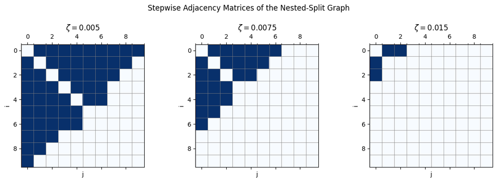

```python
import numpy as np
import networkx as nx
import matplotlib.pyplot as plt
def simulate_nested_split_rd(n, eta, rho, lam, zeta,
                             max_iter=100, tol=1e-8):
    """
    Simulate the fixed‐point (A, y) for given parameters.
    Args:
      n       : number of firms
      eta     : array‐like, length‐n vector of productivities η_i
      rho     : float, benefit parameter
      lam     : float, spill‐out parameter λ
      zeta    : float, link cost ζ
      max_iter: maximum number of updates to A,y
      tol     : convergence tolerance on max |y_new - y_old|
    Returns:
      A       : (n×n) adjacency matrix of the network
      y       : length‐n vector of R&D efforts
    """
    η = np.asarray(eta).reshape(n)
    # initialize A to no links
    A = np.zeros((n,n), dtype=int)
    # initial guess for y: just the stand‐alone η
    y = η.copy()
    for it in range(max_iter):
        # --- 1) given A, solve for y:  (I - B) y = η ---
        B = np.zeros((n,n))
        # off‐diagonal entries
        B += rho * A
        B -= lam * (np.ones((n,n)) - np.eye(n))
        # zero out diagonal
        np.fill_diagonal(B, 0.0)
        # solve (I - B) y = η
        M = np.eye(n) - B
        y_new = np.linalg.solve(M, η)
        # --- 2) update adjacency A by threshold rule ---
        thresh = zeta / rho
        # outer product y_i * y_j
        Yprod = np.outer(y_new, y_new)
        A_new = (Yprod > thresh).astype(int)
        np.fill_diagonal(A_new, 0)   # no self‐links
        # check convergence
        if np.max(np.abs(y_new - y)) < tol and np.array_equal(A_new, A):
            break
        y = y_new
        A = A_new
    return A, y

def plot_adjacency(A, ax=None):
    """Plot adjacency matrix as a heatmap."""
    if ax is None:
        fig, ax = plt.subplots()
    im = ax.matshow(A, cmap='Blues')
    ax.set_xlabel('j')
    ax.set_ylabel('i')
    ax.set_xticks(np.arange(-0.5, A.shape[1], 1), minor=True)
    ax.set_yticks(np.arange(-0.5, A.shape[0], 1), minor=True)
    ax.grid(which='minor', color='gray', linestyle='-', linewidth=0.5)
    ax.tick_params(which='minor', bottom=False, left=False)
    return ax

if __name__ == "__main__":
    # === parameters from Figure 4 ===
    n   = 10
    lam = 0.06
    rho = 0.05 # in paper, rho = 0.02
    eta = [1.00, 0.71, 0.58, 0.50, 0.45,
           0.41, 0.38, 0.35, 0.33, 0.32]
    zetas = [0.005, 0.0075, 0.015]
    # Simulate for each ζ and plot
    fig, axes = plt.subplots(1, len(zetas), figsize=(12,4))
    for ax, ζ in zip(axes, zetas):
        A, y = simulate_nested_split_rd(n, eta, rho, lam, ζ)
        ax = plot_adjacency(A, ax=ax)
        ax.set_title(fr'$\zeta={ζ}$')

    plt.suptitle("Stepwise Adjacency Matrices of the Nested‐Split Graph")
    plt.tight_layout(rect=[0,0,1,0.95])
    plt.show()
```

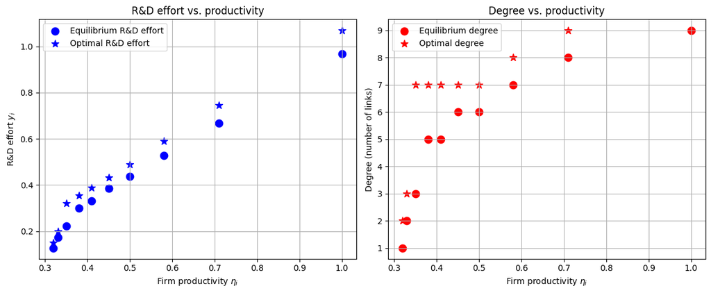

```python
# socially optimal rd effort
def simulate_nested_split_opt_rd(n, eta, rho, lam, zeta, psi,
                             max_iter=100, tol=1e-8):
    η = 1/psi * np.asarray(eta).reshape(n)
    # initialize A to no links
    A = np.zeros((n,n), dtype=int)
    # initial guess for y: just the stand‐alone η
    y = η.copy()
    for it in range(max_iter):
        # --- 1) given A, solve for y:  (I - B) y = η ---
        B = np.zeros((n,n))
        # off‐diagonal entries
        B += 1/psi * rho * A
        B -= 1/psi * lam * (np.ones((n,n)) - np.eye(n))
        # zero out diagonal
        np.fill_diagonal(B, 0.0)
        # solve (I - B) y = η
        M = np.eye(n) - B
        y_new = np.linalg.solve(M, η)
        # --- 2) update adjacency A by threshold rule ---
        thresh = zeta / rho
        # outer product y_i * y_j
        Yprod = np.outer(y_new, y_new)
        A_new = (Yprod > thresh).astype(int)
        np.fill_diagonal(A_new, 0)   # no self‐links
        # check convergence
        if np.max(np.abs(y_new - y)) < tol and np.array_equal(A_new, A):
            break
        y = y_new
        A = A_new
    return A, y
## Firm productivity and R&D effort
n   = 10
lam = 0.06
rho = 0.05 # in paper, rho = 0.02
psi = 0.90 # weight in consumer welfare
eta = [1.00, 0.71, 0.58, 0.50, 0.45,
       0.41, 0.38, 0.35, 0.33, 0.32]
zeta = 0.005
Aopt, yopt = simulate_nested_split_opt_rd(n, eta, rho, lam, zeta, psi)
A, y = simulate_nested_split_rd(n, eta, rho, lam, zeta)
fig, axes = plt.subplots(1, 2, figsize=(12, 5))
# figure1: R&D effort vs. productivity
axes[0].scatter(eta, y, color='blue', s=80)
axes[0].scatter(eta, yopt, color='blue', s=80, marker='*')
axes[0].legend(['Equilibrium R&D effort', 'Optimal R&D effort'])
axes[0].set_xlabel(r"Firm productivity $\eta_i$")
axes[0].set_ylabel(r"R&D effort $y_i$")
axes[0].set_title(r"R&D effort vs. productivity")
axes[0].grid(True)
# figure2: Degree vs. productivity
axes[1].scatter(eta, np.sum(A, axis=1), color='red', s = 80)
axes[1].scatter(eta, np.sum(Aopt, axis=1), color='red', s = 80, marker='*')
axes[1].legend(['Equilibrium degree', 'Optimal degree'])
axes[1].set_xlabel(r"Firm productivity $\eta_i$")
axes[1].set_ylabel("Degree (number of links)")
axes[1].set_title("Degree vs. productivity")
axes[1].grid(True)
plt.tight_layout()
plt.show()
```

## Empirical Analysis

- A sample of 1,738 firms with 632 R&D collaborations
- The empirical profit function of firm $i$: $$\pi_i(y_i, G) = \eta_i y_i - \frac{1}{2}y_i^2 - \rho \sum_{j=1}^n f_{ij}a_{ij}y_j y_i - \lambda \sum_{j=1}^n b_{ij}y_jy_i-\sum_{j=1}^n a_{ij}\zeta_{ij}$$
- **Parameterization**:
  - *Productivity*: $\eta_i = \mathbf{X}_i \boldsymbol{\delta} + \kappa z_i$
  - *Symmetric R&D collaboration cost*: $\zeta_{ij} = \mathbf{W}_{ij}\boldsymbol{\gamma} - z_i -z_j$
  - $z_i$ is the latent/unobserved firm heterogeneity
- **Estimation Challenge**: Computing the denominator of the stationary distribution has to consider all possible R&D collaborations in $G'$
  - **Composite likelyhood method**

### Estimation Method: Bayesian MCMC (Markov Chain Monte Carlo)

- **Bayesian goal:** Compute expectations under an intractable posterior
  $$ p(\theta\mid y)\;\propto\;p(y\mid\theta)\,p(\theta) $$
  - $p(y\mid\theta)$ is the likelihood of data given parameters $\theta$.
  - $p(\theta)$ is the prior belief.
- **Monte Carlo** methods approximate such integrals by random sampling: $$\mathbb{E}_{p(\theta|y)}[f(\theta)]\approx \frac1{S}\sum_{s=1}^S f(\theta^{(s)})$$
  - $S$ is the number of samples.
  - $\theta^{(s)}$ is a sample from $p(\theta|y)$.
- **Key idea:** Construct a Markov chain $\{\theta^{(t)}\}$ whose  
  **stationary/equilibrium distribution** is $p(\theta\mid y)$.

### Two Core Algorithms for MCMC

#### 1. Metropolis–Hastings

(1). **Propose** $\theta'\sim q(\theta'\mid\theta^{(t)})$: (a) $\theta' = \theta^{t}+\epsilon$, $\epsilon\sim N(0,\sigma^2)$ or (b) $\theta'$ drawn from a fixed distribution

(2). Compute
$$ \alpha = \min\!\biggl(1,\; \frac{p(y\mid\theta')\,p(\theta')\,q(\theta^{(t)}\mid\theta')} {p(y\mid\theta^{(t)})\,p(\theta^{(t)})\,q(\theta'\mid\theta^{(t)})} \biggr) $$ (3). **Accept** $\theta^{(t+1)}=\theta'$ with probability $\alpha$; otherwise $\theta^{(t+1)}=\theta^{(t)}$.

**Why it works**: This “Metropolis step” enforces detailed balance, guaranteeing the posterior is stationary for the chain.

#### 2. Gibbs Sampling

- Iterate over each component $i$:
  $$ \theta_i^{(t+1)} \sim p(\theta_i\mid \theta_{-i}^{(t)},\,y) $$
- Requires closed-form conditionals.

**Why it works**: Each update leaves the joint posterior invariant; under mild conditions the chain is ergodic, so it converges to the true posterior.

### Practical Tips

- Run **multiple chains** & check convergence
- Discard **burn-in** (initial transient).
- Monitor **effective sample size** & autocorrelation.
- For a typical structural estimation, the estimation usually takes days!

**Example: a simple M-H Markov Chain** Below is an example of using a simple Metropolis–Hastings Markov chain Monte Carlo to estimate the posterior of the mean $\mu$ of a Normal model with known variance.

- Observed data: $\log p(y \mid \mu)= -\frac{n}{2}\log(2\pi\sigma^2)\;-\;\frac{1}{2\sigma^2}\sum_{i=1}^n (y_i - \mu)^2$
- Prior: $\log p(\mu)= -\frac{1}{2}\log(2\pi\tau^2) \;-\;\frac{\mu^2}{2\tau^2}$
- Posterior (after dropping constants): $\log p(\mu \mid y)\;\propto\; -\frac{1}{2\sigma^2}\sum_{i=1}^n (y_i - \mu)^2\;-\;\frac{\mu^2}{2\tau^2}$

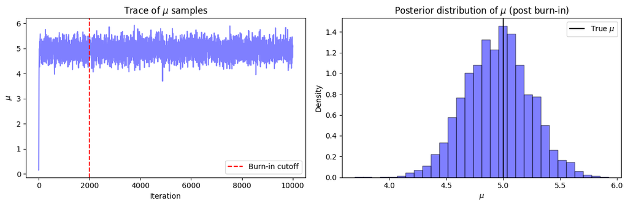

```
-------------------------------------
True value    :  5.000
Posterior mean estimate: 4.949
Posterior std estimate: (0.284)
-------------------------------------
```

```python
# Bayesian inference using Metropolis-Hastings with Gaussian Random Walk
# Generate synthetic data
np.random.seed(1)
true_mu = 5.0
sigma = 2.0   # known standard deviation
n_samples = 50
data = np.random.normal(loc=true_mu, scale=sigma, size=n_samples)
tau = 10.0
# Log-posterior (up to a constant)
def log_post(mu, data, sigma, tau):
    ll = -0.5 * np.sum((data - mu)**2) / sigma**2  # log-likelihood
    lp = -0.5 * mu**2 / tau**2                    # log-prior
    return ll + lp
# Metropolis-Hastings sampler
def metropolis_hastings(log_post, data, sigma, tau, initial_mu, proposal_std, n_iters):
    mu_current = initial_mu
    logp_current = log_post(mu_current, data, sigma, tau)
    samples = np.zeros(n_iters)
    for i in range(n_iters):
        mu_proposal = np.random.normal(mu_current, proposal_std) #Gaussian proposal
        logp_proposal = log_post(mu_proposal, data, sigma, tau)
        # acceptance probability
        log_alpha = logp_proposal - logp_current
        if np.log(np.random.rand()) < log_alpha:
            mu_current = mu_proposal
            logp_current = logp_proposal
        samples[i] = mu_current
    return samples
# Run the sampler
n_iters = 10000
proposal_std = 0.5
initial_mu = 0.0
samples = metropolis_hastings(
    log_posterior, data, sigma, tau, initial_mu, proposal_std, n_iters
)
# Discard burn-in
burn_in = 2000 #dropping first 2000 samples
posterior_samples = samples[burn_in:]
fig, axes = plt.subplots(1, 2, figsize=(12, 4))

# Trace plot
axes[0].plot(samples, alpha=0.5, color='blue')
axes[0].axvline(burn_in, color='red', linestyle='--', label='Burn-in cutoff')
axes[0].set_title(r'Trace of $\mu$ samples')
axes[0].set_xlabel(r'Iteration')
axes[0].set_ylabel(r'$\mu$')
axes[0].legend()

# Posterior histogram
axes[1].hist(posterior_samples, bins=30, density=True, alpha=0.5, color='blue', edgecolor='black')
axes[1].axvline(true_mu, color='black', linestyle='-', label=r'True $\mu$')
axes[1].set_title(r'Posterior distribution of $\mu$ (post burn-in)')
axes[1].set_xlabel(r'$\mu$')
axes[1].set_ylabel('Density')
axes[1].legend()

plt.tight_layout()
plt.show()

# Print summary
print("-------------------------------------")
print(f"True value    :  {true_mu:.3f}")
print(f"Posterior mean estimate: {np.mean(posterior_samples):.3f}")
print(f"Posterior std estimate: ({np.std(posterior_samples):.3f})")
print("-------------------------------------")
```

## Extensions and Takeaways

This paper provides a framework with many extensions and potential applications (probably more than an RAND publication!):

- NO GROWTH!
- Can introduce non-collaborative R&D spillovers, which further drive down the R&D collaboration incentives:
  - Firms can free-ride on other firms' R&D efforts, even if they do not collaborate with them: internal vs. external R&D spillovers
  - Revaluate the problem of optimal R&D allocation, R&D subsidy, etc.
  - In **directed spillover networks**, subsidizing the upstream and key collaboration note is the most effective way
- The consequence of the breakdown/promoting of R&D collaborations
  - Industrial policy/Geopolitics promoting domestic R&D collaborations BUT not overseas collaborations
  - Global innovation networks in key industries (e.g., semiconductors, AI, etc.)
  - Promoting industry-Academia-Research collaborations (产学研结合)
- Not only limited to R&D collaborations:
  - **Environmental Economics**: trading of carbon emission rights
  - **Corporate Finance**: ownership networks